# Project2_BENN

Maleah Benn

2/16/2022

# 2073 - Project 2

## Feb. 16, 2022

# Load packages

```r
# load packages
library(tidyverse)
```

```r
library(ggplot2)
library(RColorBrewer)
library(zoo)
```

# Read in files

```r
# read in files
expr1 <- read.csv("C:/Users/Maleah/Desktop/Pitt/Spring 2022/2073 - Visualization/Project 2/exampleExpr1.csv", header = TRUE)

fake4 <- read.csv("C:/Users/Maleah/Desktop/Pitt/Spring 2022/2073 - Visualization/Project 2/fake4ConnectedScatter.csv", header = TRUE)

OG <- read.delim("C:/Users/Maleah/Desktop/Pitt/Spring 2022/2073 - Visualization/Project 2/OGs_used_NG.txt", header = FALSE)

# rename column here
OG <- OG %>% rename(gene_name = V1)

TSG <- read.delim("C:/Users/Maleah/Desktop/Pitt/Spring 2022/2073 - Visualization/Project 2/TSGs_used_NG.txt", header = FALSE)

# rename column here
TSG <- TSG %>% rename(gene_name = V1)

phast <- read.delim("C:/Users/Maleah/Desktop/Pitt/Spring 2022/2073 - Visualization/Project 2/phastCons100Verts.txt", header = FALSE, skip = 9)

phylo <- read.delim("C:/Users/Maleah/Desktop/Pitt/Spring 2022/2073 - Visualization/Project 2/phyloPCons100Verts.txt", header = FALSE, skip = 9)
```

# Question 1

## 1.1 Distribution of expression values in genes with expression values > 5

```
## [1] 20530     2
```

```
##      sample TCGA.BH.A0C7.01
## 1 ARHGEF10L         10.0931
## 2     HIF3A          3.6090
## 3     RNF17          0.0000
## 4     RNF10         11.3820
## 5     RNF11         10.7663
## 6     RNF13         10.3366
```

```
##       sample TCGA.BH.A0C7.01
## 20525  TULP3          9.5725
## 20526   PTRF         11.8181
## 20527  BCL6B          7.9077
## 20528  GSTK1         10.7539
## 20529   SELP          6.5823
## 20530   SELS          9.7063
```

```
## [1] 13529     2
```

```
##      sample TCGA.BH.A0C7.01
## 1 ARHGEF10L         10.0931
## 2     RNF10         11.3820
## 3     RNF11         10.7663
## 4     RNF13         10.3366
## 5   GTF2IP1         12.7240
## 6   RTN4RL2          5.0910
```

```
##       sample TCGA.BH.A0C7.01
## 13524  TULP3          9.5725
## 13525   PTRF         11.8181
## 13526  BCL6B          7.9077
## 13527  GSTK1         10.7539
## 13528   SELP          6.5823
## 13529   SELS          9.7063
```

```
##    sample TCGA.BH.A0C7.01
## 1    DIO1          5.0117
## 2   ACCN3          5.0117
## 3 ZNF280B          5.0117
## 4   LRFN5          5.0117
## 5  SNHG10          5.0117
## 6  PIK3R6          5.0117
```

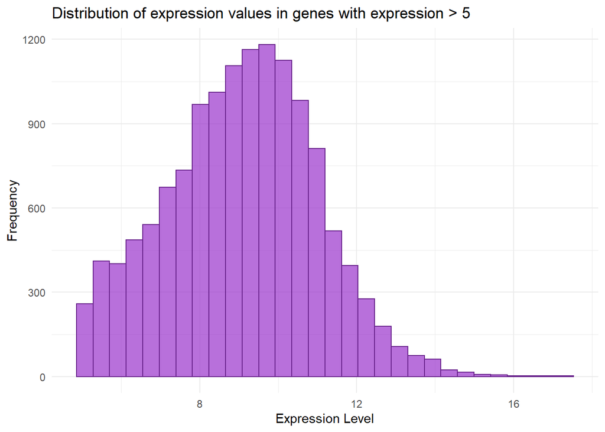

## 1.2 QQ against a normal distribution

```r
# z transform expression (mean = 0, variance = 1)
expr1_5 <- expr1_5 %>% mutate(scaled.exp = (expr1_5$TCGA.BH.A0C7.01 - mean(expr1_5$TCGA.BH.A0C7.01)) / sd(expr1_5$TCGA.BH.A0C7.01))

# check
head(expr1_5)
```

```
##      sample TCGA.BH.A0C7.01 scaled.exp
## 1 ARHGEF10L         10.0931  0.5360552
## 2     RNF10         11.3820  1.2070090
## 3     RNF11         10.7663  0.8864983
## 4     RNF13         10.3366  0.6628123
## 5   GTF2IP1         12.7240  1.9056047
## 6   RTN4RL2          5.0910 -2.0678534
```

```r
mean(expr1_5$scaled.exp) # pretty much 0, good
```

```
## [1] -2.132467e-16
```

```r
mean(var(expr1_5$scaled.exp)) # 1, good
```

```
## [1] 1
```

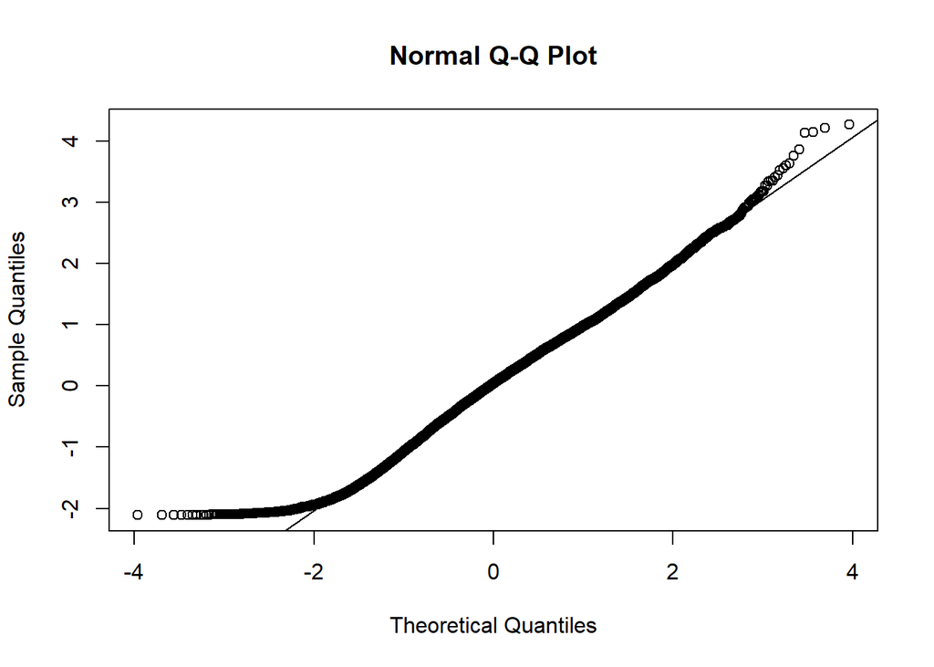

```r
# qqplot with normal distribution
qqnorm(expr1_5$scaled.exp)
qqline(expr1_5$scaled.exp)
```

## 1.3 KS Test against normal

```r
# KS test of z transformed data against normal distribution
ks.test(expr1_5$scaled.exp, pnorm)
```

```
##
##  One-sample Kolmogorov-Smirnov test
##
## data:  expr1_5$scaled.exp
## D = 0.020398, p-value = 2.58e-05
## alternative hypothesis: two-sided
```

### 1.3 Explanation

The KS test comparing our filtered and transformed data to a normal distribution gave a p-value of 2.58e-5 and a test statistic, D, of 0.02. The results of the KS test were significant indicating that it is likely our data was sampled from a population that does not follow a normal distribution for these expression levels.

# Question 2

## 2.1 Show both features over time

```r
# look at data
dim(fake4)
```

```
## [1] 46  3
```

```r
head(fake4)
```

```
##   ï..Time.point featA  featB
## 1             1 46.11  99.79
## 2             2 53.67 107.35
## 3             3 61.99 109.61
## 4             4 67.28 102.81
## 5             5 69.55  95.25
## 6             6 65.01  87.69
```

```r
tail(fake4)
```

```
##    ï..Time.point  featA featB
## 41            41 127.76 38.55
## 42            42 131.54 51.40
## 43            43 136.07 61.23
## 44            44 143.63 70.30
## 45            45 152.70 75.60
## 46            46 167.82 83.91
```

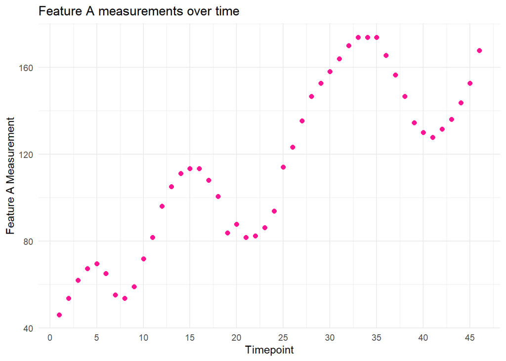

```r
# rename timepoint column so I can access it easier
fake4 <- fake4 %>% rename(time = ï..Time.point)

# create breaks
breaks <- seq(0,50,5)

# scatterplot of feature A
scatter_a <- ggplot(fake4, aes(x=time, y=featA)) +
  geom_point(color = "deeppink", size = 2) +
  scale_x_continuous(breaks=breaks, labels=as.character(breaks)) +
  labs(title = "Feature A measurements over time",
       x = "Timepoint",
       y = "Feature A Measurement") +
  theme_minimal()

scatter_a
```

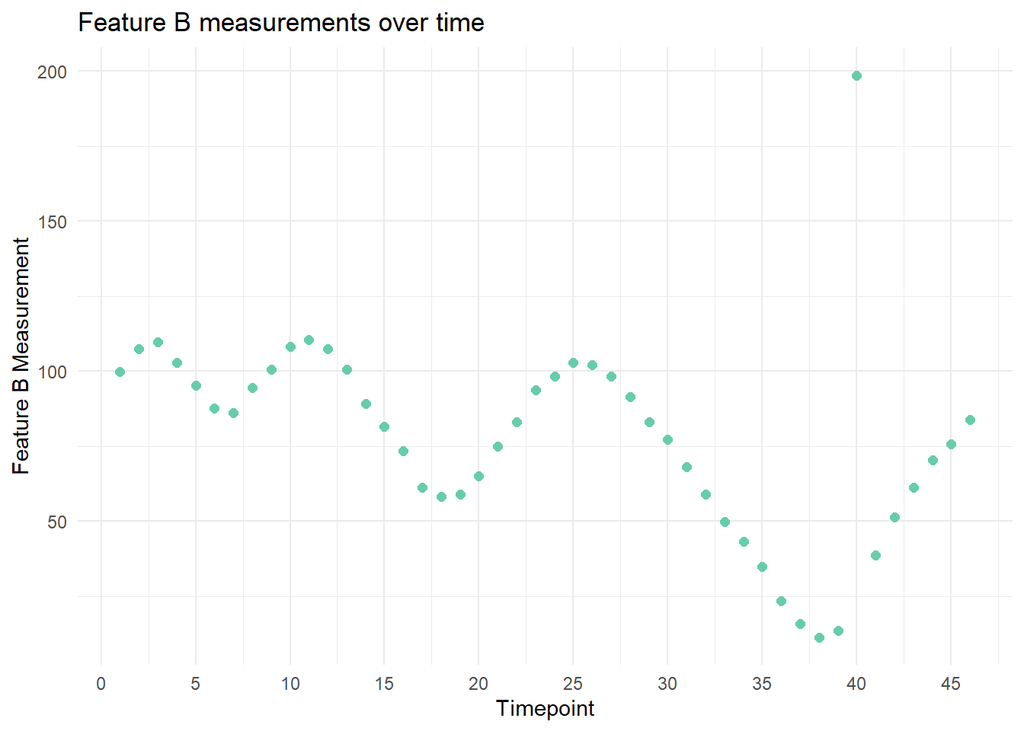

```r
# scatterplot of feature B
scatter_b <- ggplot(fake4, aes(x=time, y=featB)) +
  geom_point(color = "aquamarine3", size = 2) +
  scale_x_continuous(breaks=breaks, labels=as.character(breaks)) +
  labs(title = "Feature B measurements over time",
       x = "Timepoint",
       y = "Feature B Measurement") +
  theme_minimal()

scatter_b
```

## 2.2 Feature A vs Feature B

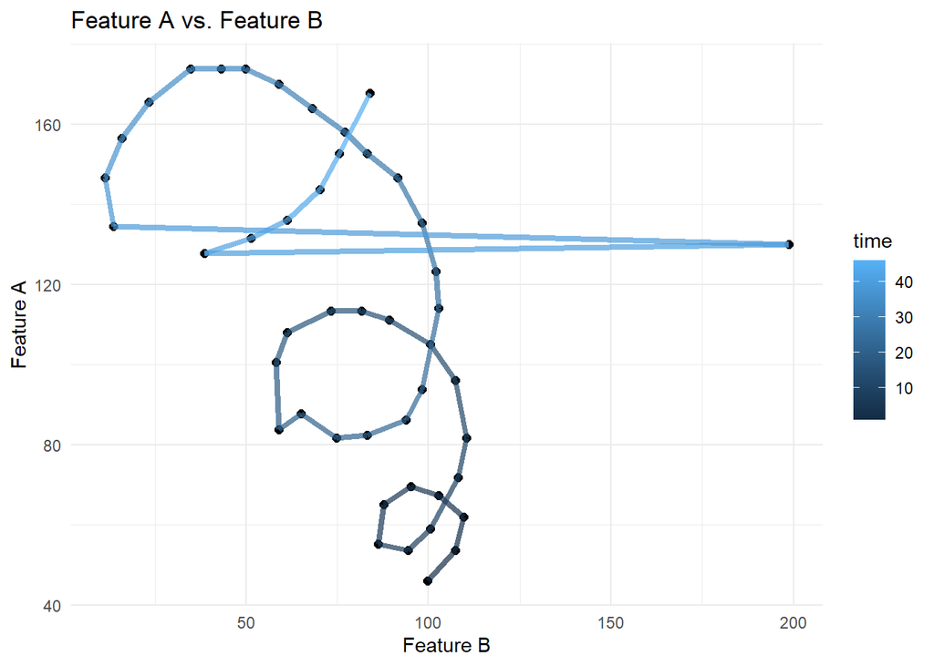

```r
# scatterplot of A vs B
AvB <- ggplot(fake4, aes(x=featB, y=featA)) +
  geom_point(size = 2) +
  labs(title = "Feature A vs. Feature B",
       x = "Feature B",
       y = "Feature A") +
  geom_path(aes(color = time), size = 1.5, alpha = 0.7) +
  theme_minimal()

AvB
```

### 2.3 Explanation of feature A and feature B

As time progresses, feature A appears to cyclically increase pretty steadily according to ‘scatter_a’. Conversely, feature B appears to cyclically decrease at a slower rate than feature A increases, according to ‘scatter_b’. Additionally, there appears to be one point in feature B at time = 40 that does not follow the rest of the pattern. Looking at plot ‘AvB’, we can see that feature B starts around 100 while feature A starts around 45. The color of the line indicates time progressing, where the line becomes lighter as time moves forward. The two features appear to move in the same direction periodically, around time points 0-2, 6-11, 18-25, and 38-46.

# Question 3

## 3.1 Sliding window plots

```r
# add column names to phast
colnames(phast) <- c("bp","metric_1")

# add column names to phylo
colnames(phylo) <- c("bp","metric_2")

# check
head(phast)
```

```
##         bp   metric_1
## 1 15560138 0.00000000
## 2 15560139 0.00000000
## 3 15560140 0.00787402
## 4 15560141 0.00787402
## 5 15560142 0.01574800
## 6 15560143 0.01574800
```

```r
head(phylo)
```

```
##         bp  metric_2
## 1 15560138  0.148315
## 2 15560139 -0.329417
## 3 15560140  0.466803
## 4 15560141  0.188126
## 5 15560142  0.387181
## 6 15560143  0.466803
```

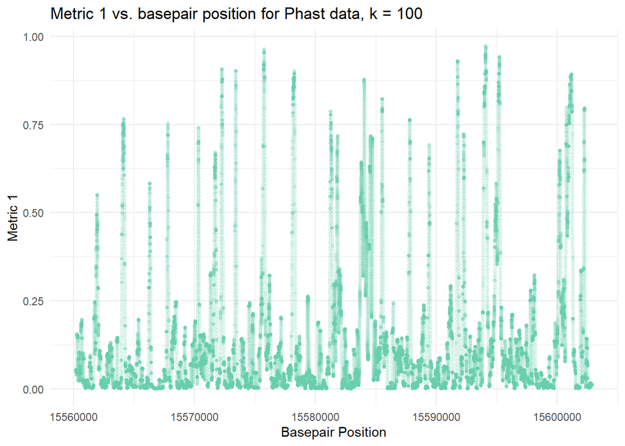

```r
# sliding plots for phast
## phast1
phast_1 <- data.frame(rollmean(phast, 100, fill = NA))

phast_1_plot <- ggplot(phast_1, aes(x=bp, y=metric_1)) +
  geom_point(color = "aquamarine3", size = 1, alpha = 0.2) +
  labs( title = "Metric 1 vs. basepair position for Phast data, k = 100",
        x = "Basepair Position",
        y = "Metric 1") +
  theme_minimal()

phast_1_plot
```

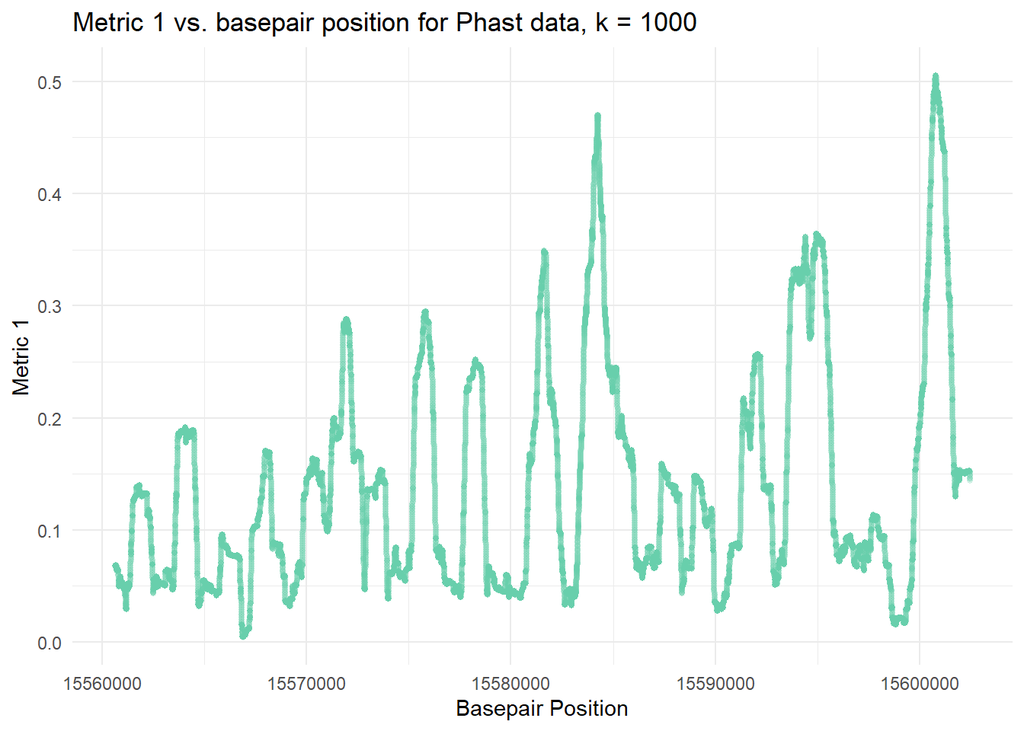

```r
## phast2
phast_2 <- data.frame(rollmean(phast, 1000, fill = NA))
phast_2_plot <- ggplot(phast_2, aes(x=bp, y=metric_1)) +
  geom_point(color = "aquamarine3", size = 1, alpha = 0.2) +
  labs( title = "Metric 1 vs. basepair position for Phast data, k = 1000",
        x = "Basepair Position",
        y = "Metric 1") +
  theme_minimal()

phast_2_plot
```

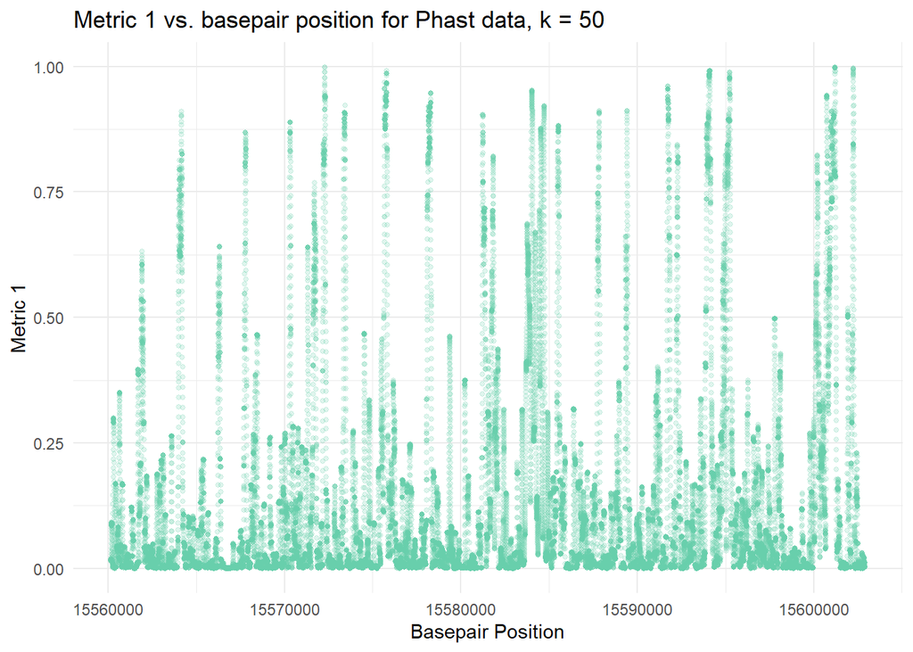

```r
## phast3
phast_3 <- data.frame(rollmean(phast,50, fill = NA))
phast_3_plot <- ggplot(phast_3, aes(x=bp, y=metric_1)) +
  geom_point(color = "aquamarine3", size = 1, alpha = 0.2) +
  labs( title = "Metric 1 vs. basepair position for Phast data, k = 50",
        x = "Basepair Position",
        y = "Metric 1") +
  theme_minimal()

phast_3_plot
```

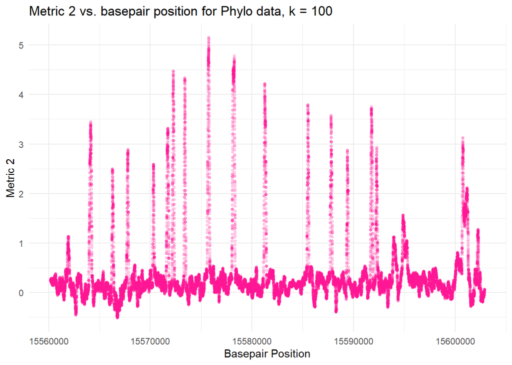

```r
# sliding plots for phylo
## phylo1
phylo_1 <- data.frame(rollmean(phylo, 100, fill = NA))

phylo_1_plot <- ggplot(phylo_1, aes(x=bp, y=metric_2)) +
  geom_point(color = "deeppink", size = 1, alpha = 0.2) +
  labs( title = "Metric 2 vs. basepair position for Phylo data, k = 100",
        x = "Basepair Position",
        y = "Metric 2") +
  theme_minimal()

phylo_1_plot
```

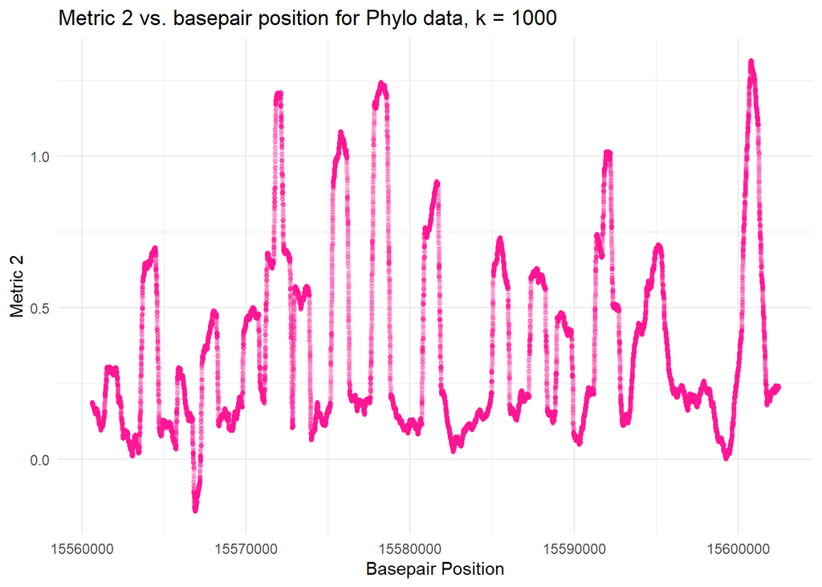

```r
## phylo2
phylo_2 <- data.frame(rollmean(phylo, 1000, fill = NA))

phylo_2_plot <- ggplot(phylo_2, aes(x=bp, y=metric_2)) +
  geom_point(color = "deeppink", size = 1, alpha = 0.2) +
  labs( title = "Metric 2 vs. basepair position for Phylo data, k = 1000",
        x = "Basepair Position",
        y = "Metric 2") +
  theme_minimal()

phylo_2_plot
```

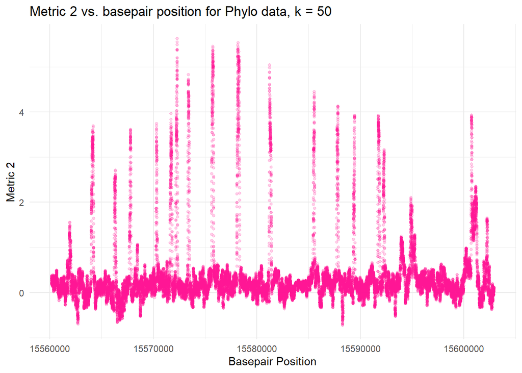

```r
## phylo3
phylo_3 <- data.frame(rollmean(phylo, 50, fill = NA))

phylo_3_plot <- ggplot(phylo_3, aes(x=bp, y=metric_2)) +
  geom_point(color = "deeppink", size = 1, alpha = 0.2) +
  labs( title = "Metric 2 vs. basepair position for Phylo data, k = 50",
        x = "Basepair Position",
        y = "Metric 2") +
  theme_minimal()

phylo_3_plot
```

## 3.2 Optimal sliding window parameters

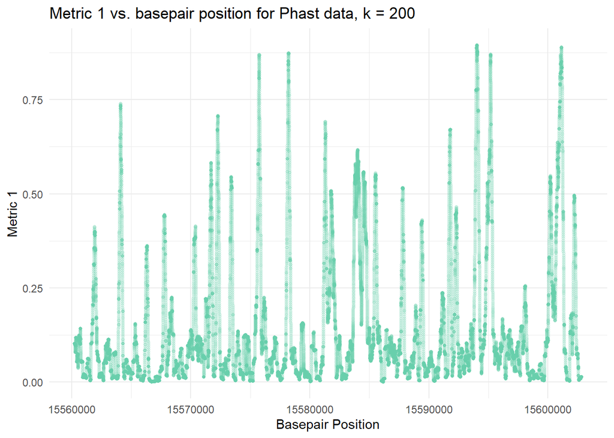

```r
# optimal phast plot
phast_4 <- data.frame(rollmean(phast,200, fill = NA))
phast_4_plot <- ggplot(phast_4, aes(x=bp, y=metric_1)) +
  geom_point(color = "aquamarine3", size = 1, alpha = 0.2) +
  labs( title = "Metric 1 vs. basepair position for Phast data, k = 200",
        x = "Basepair Position",
        y = "Metric 1") +
  theme_minimal()

phast_4_plot
```

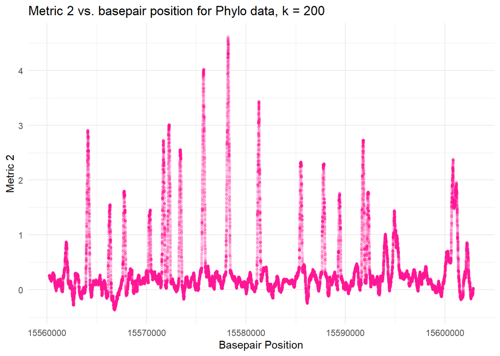

```r
# optimal phylo plot
phylo_4 <- data.frame(rollmean(phylo, 200, fill = NA))

phylo_4_plot <- ggplot(phylo_4, aes(x=bp, y=metric_2)) +
  geom_point(color = "deeppink", size = 1, alpha = 0.2) +
  labs( title = "Metric 2 vs. basepair position for Phylo data, k = 200",
        x = "Basepair Position",
        y = "Metric 2") +
  theme_minimal()

phylo_4_plot
```

### 3.2 Explanations

After adjusting parameters for both the phast and phylo data, k=200 seems to give a decent picture of the data for both metrics. When adjusting k to less than 100, the graphs become too granular and it is difficult to distinguish actual peaks from noise. When the k is set too high, it oversimplifies any underlying trends in the data that may be important.

# Question 4

## 4.1 Filter by log2(FPKM) > 2

```r
# filter
expr1_2 <- expr1 %>% filter(TCGA.BH.A0C7.01 > 2)

# check
dim(expr1_2)
```

```
## [1] 15884     2
```

```r
head(expr1_2)
```

```
##      sample TCGA.BH.A0C7.01
## 1 ARHGEF10L         10.0931
## 2     HIF3A          3.6090
## 3     RNF10         11.3820
## 4     RNF11         10.7663
## 5     RNF13         10.3366
## 6   GTF2IP1         12.7240
```

```r
tail(expr1_2)
```

```
##       sample TCGA.BH.A0C7.01
## 15879  TULP3          9.5725
## 15880   PTRF         11.8181
## 15881  BCL6B          7.9077
## 15882  GSTK1         10.7539
## 15883   SELP          6.5823
## 15884   SELS          9.7063
```

## 4.2 Sample 500 expressed genes

```r
# sample
expressed_samp <- sample(expr1_2$sample, 500)

# check
str(expressed_samp)
```

```
##  chr [1:500] "CCNT2" "PLEKHG5" "FAM171B" "LRRC47" "SNX22" "CALML4" "BZRAP1" ...
```

## 4.3 Select only TSG and OG genes from 500 sample

```r
# add descriptions to TSG and OG
TSG <- TSG %>% mutate(gene_type = "TSG")
OG <- OG %>% mutate(gene_type = "OG")

# check
head(TSG)
head(OG)

# combine
TSGnOG <- rbind(TSG,OG)

# check
head(TSGnOG)
tail(TSGnOG)

# make into df
expressed_samp <- data.frame(expressed_samp)

# change column name
expressed_samp <- expressed_samp %>% rename(gene_name = expressed_samp)

# filter sample down to only TSG and OG
exp_samp_filt <- expressed_samp %>% filter(gene_name %in% TSGnOG$gene_name)

# check
dim(exp_samp_filt)
head(exp_samp_filt)
tail(exp_samp_filt)

# merge
exp_samp_filt <- left_join(exp_samp_filt, TSGnOG, by.x = gene_name, by.y = gene_name)
# check
dim(exp_samp_filt)
head(exp_samp_filt)
```

[output not shown]

## 4.4 Chi2 test of OG and TSG within 500 sample

```r
# chi2 of exp_samp_filt
## get counts of TSG in sample
n_TSG <- sum(exp_samp_filt[2] == "TSG")
n_TSG

## get counts of OG in sample
n_OG <- sum(exp_samp_filt[2] == "OG")
n_OG

## create X
X <- c(TSG = n_TSG, OG = n_OG)

## run chi2
chisq.test(X)
```

[output not shown]

## 4.5 Loop over 4.2-4.4 and plot histogram of p-values

```
## [1] 68  1
```

```
##       chi2_p
## 1 0.03959176
## 2 0.04986020
## 3 0.01430588
## 4 0.02780690
## 5 0.02780690
## 6 0.03300626
```

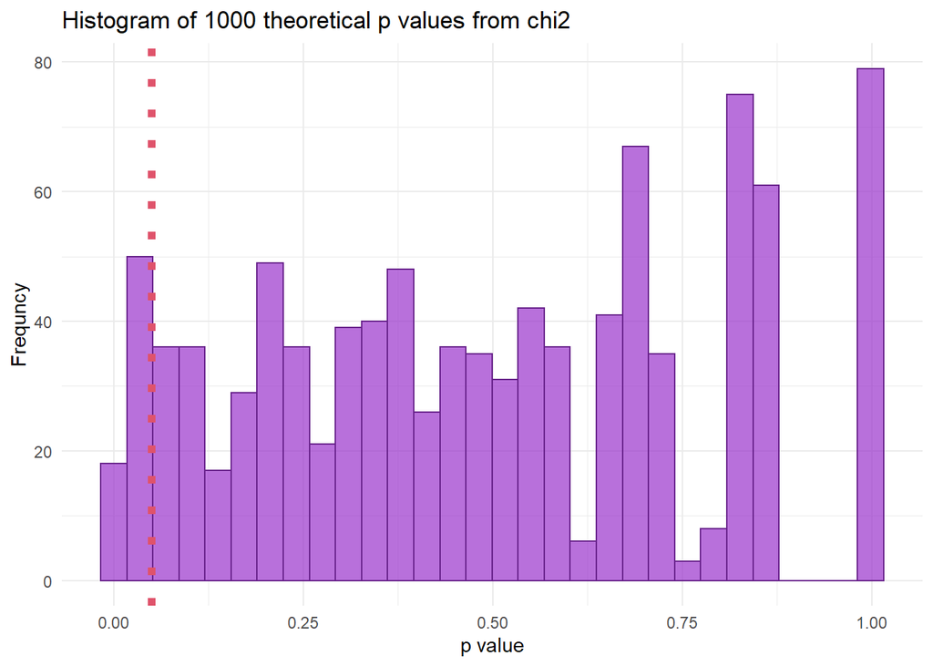

# Question 5

## 5.1 Hierarchical cluster plot

Hierarchical cluster plots use a dendrogram format but create a circle where the outside groupings can be labeled and designated using different clusters. These plots, like dendrograms, use nodes and edges to represent multiple dimensions in a dataset.

## 5.2 Dendrogram

Dendrograms use nodes and edges to represent dimensions. Nodes are where the data splits into more categories (can be parent, intermediate, or terminal node) and edges represent the relationship. The distance between two points can also be calculated using dendrograms.

## 5.3 K-means clustering

K-means clustering allows you to see how datapoints cluster based on their means. This is similar to PCA for ancestry. You can calculate the distance metric (multiple ways to do this) to determine how far away means are from one another to determine that point’s cluster on a plot.

## 5.4 Loading plots

Loading plots can be used to show how strongly each dimension influences a principal component. The angles between the variables shows how they correlate to each other. The bottom axis represents PC1, the left axis represents PC2, the top x axis shows loadings on PC1, and the right y axis is loadings on PC2.

## 5.5 t-SNE plot

t-SNE plots are similar to PCA plots. They show different groupings of your data points, but in t-SNE plots, the neighboring cluster is important as well. The distance between clusters or individual points represents their similarity to each other. The x- and y- axes are non-linear on t-SNE plots and these are typically only used for data exploration.